# 606_Presentation_531

SantoshCheruku

March 24, 2019

5.31 Chicken diet and weight, Part I. Chicken farming is a multi-billion dollar industry, and any methods that increase the growth rate of young chicks can reduce consumer costs while increasing company profits, possibly by millions of dollars. An experiment was conducted to measure and compare the effectiveness of various feed supplements on the growth rate of chickens. Newly hatched chicks were randomly allocated into six groups, and each group was given a different feed supplement. Below are some summary statistics from this data set along with box plots showing the distribution of weights by feed type.41

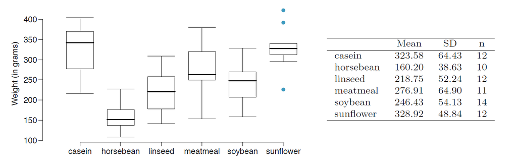

1. Describe the distributions of weights of chickens that were fed linseed and horsebean.  
   **Answer: The distributions of weights of chicken fed with linseed and horsebean are normal but horsebean has slight right skew.**
2. Do these data provide strong evidence that the average weights of chickens that were fed linseed and horsebean are different? Use a 5% significance level.

**Answer: Assuming a hypothesis test**  
H0 - Weights of chicken fed linseed and horsebean are same.  
HA - Weight of chicken fed linseed and horsebean are not same.

```r
#Horsebean fed chicken Stats
hbMean <- 160.20
hbSd <- 38.63
hn <- 10

#Linseed fed chicken Stats
lsMean <- 218.75
lsSd <- 52.24
ln <- 12

a <- .05
df <- min(hn-1, ln-1)
t <- ((218.75-160.20 ) - 0)/ sqrt(((hbSd^2) / hn) + ((lsSd^2) / ln))
p <- pt(t, df, lower.tail = F) * 2
p
```

```
## [1] 0.01455232
```

```r
ifelse(p<a, "Reject null hypothesis", "Fail to reject null hypothesis")
```

```
## [1] "Reject null hypothesis"
```

3. What type of error might we have committed? Explain.  
   **Answer: Since we are rejecting null hypothesis, we may have committed a type1 error. Which means, there is a possibility of mean weights being similar for linseed and horsebean fed chickens, but we mistakenly rejected it.**
4. Would your conclusion change if we used a = 0.01?  
   **Answer: If we change the alpha to .01 then yes, our conclusion will change since our P value will be larger than .01**